# xG Pipeline

Jack Davis

2026-07-02

# The Plan

1. Getting the data
2. Filtering the data
3. Building a basic xG Model
4. Improving the model

# 1. Getting the data

Ideally, you should be able to use the appropriate R package and download the data from there. If you’re doing something niche, you may need to use more custom methods like building your own scraper, or running optical character recognition (OCR) from image files or PDFs.

Just because a data gathering method worked in the past doesn’t mean it will continue to work.

For example, the original plan for this tutorial was to use the WorldfootballR to get shot details from the website Understat. Since the last time I got this data about a year ago, Understat has made scraping this information from the HTML source impossible.

# 1. Getting the data

…so I pivoted to hockey and the hockeyR package, which has the history play-by-play data for all NHL games as a file on its Github, but only up to the 2023-24 season.

That’s why today is about hockey data and not soccer/football data.

Having said that, I want to give a shout out to Devin Pleuler, because I also complained on Linkedin about how it’s getting hard to get play-by-play level data, and he came through with a link to his StatsBomb Github https://github.com/statsbomb/open-data , which has thousands of soccer games of event-level data in JSON format that we can use freely.

# 1. Getting the data

Let’s talk a little more about how to get sports data. Usually what we’re looking for is “event data”, or “play-by-play data” for something like an xG model, but if we want to go deeper, what we really want is “player tracking data”.

Apparently APIfy at https://apify.com/ has scrapers that you can use to get event data, but I haven’t looked at it yet (maybe next semester? I’m taking requests for tutorials and talks right now) https://apify.com/jungle_synthesizer/thesportsdb-multi-sport-api-wrapper

Similarly, https://www.thestatsapi.com/ charges for use and I haven’t tested it. The website https://www.football-data.co.uk/data.php has historical data, but not at the event level. It would be good enough to make a bracketeering application.

# 1. Getting the data

Lars Skytte’s website https://hockey-statistics.com/data/ has event data and shifts data for the NHL up historically up to 2025, and seems to be chugging right along using the NHL’s API. The website also has Profession Women’s Hockey League (PWHL) data.

Lars also writes blog posts about things like the xG model, so we can use that as guidance for our own work.

# 1. Getting the data

Let’s use the hockeyR data

```r
library(stringr)
library(hockeyR)#found in sportsdataverse
library(plyr)
library(dplyr)#for organizing data
```

```r
library(ggplot2)
pbp24=load_pbp('2023-24') # downloads the pbp file from github
```

# 2. Filtering the data

What does the data look like?

```r
pbp24 = data.frame(pbp24)
dim(pbp24)
```

```
## [1] 441371    139
```

```r
names(pbp24)
```

```
##   [1] "event_type"               "event"
##   [3] "secondary_type"           "event_team"
##   [5] "event_team_type"          "description"
##   [7] "period"                   "period_seconds"
##   [9] "period_seconds_remaining" "game_seconds"
##  [11] "game_seconds_remaining"   "home_score"
##  [13] "away_score"               "event_player_1_name"
##  [15] "event_player_1_type"      "event_player_2_name"
##  [17] "event_player_2_type"      "event_player_3_name"
##  [19] "event_player_3_type"      "event_goalie_name"
##  [21] "strength_state"           "strength_code"
##  [23] "strength"                 "event_idx"
##  [25] "num_on"                   "players_on"
##  [27] "num_off"                  "players_off"
##  [29] "extra_attacker"           "x"
```

[output cut: 55 more lines]

# 2. Filtering the data

What does the data look like?

```r
pbp24 = data.frame(pbp24)
head(pbp24, n=4)
```

```
##     event_type        event secondary_type          event_team event_team_type
## 1 PERIOD_START period-start           <NA>                <NA>            <NA>
## 2      FACEOFF      faceoff           <NA> Pittsburgh Penguins            home
## 3          HIT          hit           <NA> Pittsburgh Penguins            home
## 4         SHOT shot-on-goal       backhand Pittsburgh Penguins            home
##                                       description period period_seconds
## 1                               Start of Period 1      1              0
## 2 Sidney Crosby faceoff won against Connor Bedard      1              0
## 3                    Jake Guentzel hit Seth Jones      1             35
## 4    Bryan Rust shot on goal saved by Petr Mrazek      1             40
##   period_seconds_remaining game_seconds game_seconds_remaining home_score
## 1                     1200            0                   3600          0
## 2                     1200            0                   3600          0
## 3                     1165           35                   3565          0
## 4                     1160           40                   3560          0
```

[output cut: 120 more lines]

# 2. Filtering the data

What does the data look like?

```r
table(pbp24$period)
```

```
##
##      1      2      3      4      5
## 147573 147883 139951   4899   1065
```

```r
table(pbp24$season_type)
```

```
##
##      2   POST    REG
## 169403  31994 239974
```

```r
table(pbp24$event_type)
```

```
##
##        BLOCKED_SHOT     DELAYED_PENALTY             FACEOFF FAILED_SHOT_ATTEMPT
##               48121                3608               79532                  13
##            GAME_END            GIVEAWAY                GOAL                 HIT
##                1400               21827                8772               62134
##         MISSED_SHOT             PENALTY          PERIOD_END        PERIOD_START
##               38206               10701                4574                4574
##   SHOOTOUT_COMPLETE                SHOT                STOP            TAKEAWAY
##                  82               76160               62063               19604
```

# 2. Filtering the data

Filter out the playoff games (`season_type = "POST"`) and the overtime plays (`period > 3`).

```r
nrow(pbp24)
```

```
## [1] 441371
```

```r
pbp24=subset(pbp24,period<=3 & season_type!="POST")
nrow(pbp24)
```

```
## [1] 404389
```

.

.

.

.

# 2. Filtering the data

Look only at shots and attempted shots.

```r
df_shots=subset(pbp24,event_type%in%c("SHOT",
          "BLOCKED_SHOT","FAILED_SHOT_ATTEMPT",
          "MISSED_SHOT","GOAL"))
nrow(df_shots)
```

```
## [1] 157838
```

Remove the rare cases where the team shooting wasn’t recorded.

```r
df_shots=subset(df_shots,!is.na(event_team))
nrow(df_shots)
```

```
## [1] 157829
```

.

.

.

.

# 2. Filtering the data

If we don’t know the secondary event type (e.g., shot type), use the primary event type in its place. This is the case for a few goals, missed shots

```r
table(df_shots$secondary_type, df_shots$event_type, useNA = "always")
```

```
##
##                BLOCKED_SHOT FAILED_SHOT_ATTEMPT  GOAL MISSED_SHOT  SHOT  <NA>
##   backhand                0                   0   658        2164  5148     0
##   bat                     0                   0    55         187   177     0
##   between-legs            0                   0     9          25    43     0
##   cradle                  0                   0     3           3     3     0
##   deflected               0                   0   189         936  1169     0
##   poke                    0                   0    56          58   326     0
##   slap                    0                   0   664        4769  7918     0
##   snap                    0                   0  1457        4356  9889     0
##   tip-in                  0                   0   831        4449  4697     0
##   wrap-around             0                   0    56         260   576     0
##   wrist                   0                   0  3905       17539 40265     0
##   <NA>                44375                   3    13         237   361     0
```

```r
df_shots$secondary_type[is.na(df_shots$secondary_type)]=
      df_shots$event_type[is.na(df_shots$secondary_type)]
```

```r
table(df_shots$secondary_type, df_shots$event_type)
```

```
##
##                       BLOCKED_SHOT FAILED_SHOT_ATTEMPT  GOAL MISSED_SHOT  SHOT
##   backhand                       0                   0   658        2164  5148
##   bat                            0                   0    55         187   177
##   between-legs                   0                   0     9          25    43
##   BLOCKED_SHOT               44375                   0     0           0     0
##   cradle                         0                   0     3           3     3
##   deflected                      0                   0   189         936  1169
##   FAILED_SHOT_ATTEMPT            0                   3     0           0     0
##   GOAL                           0                   0    13           0     0
##   MISSED_SHOT                    0                   0     0         237     0
##   poke                           0                   0    56          58   326
##   SHOT                           0                   0     0           0   361
##   slap                           0                   0   664        4769  7918
##   snap                           0                   0  1457        4356  9889
##   tip-in                         0                   0   831        4449  4697
##   wrap-around                    0                   0    56         260   576
##   wrist                          0                   0  3905       17539 40265
```

.

.

.

.

# 2. Filtering the data

Mark the ones that were otherwise goals in the secondary type (shot type) as shots. Does the proportion of shot attempts that end up goals make sense? About 5%?

```r
df_shots$secondary_type[df_shots$secondary_type=="GOAL"]="SHOT"

df_shots$is_goal=1*(df_shots$event_type=="GOAL")

table(df_shots$is_goal)
```

```
##
##      0      1
## 149933   7896
```

```r
mean(df_shots$is_goal)
```

```
## [1] 0.05002883
```

# 3. Building the xG Model

Now we’re ready to build the xG model. We know that distance to the net is a key factor. We can see from the graph of shot locations where the nets are.

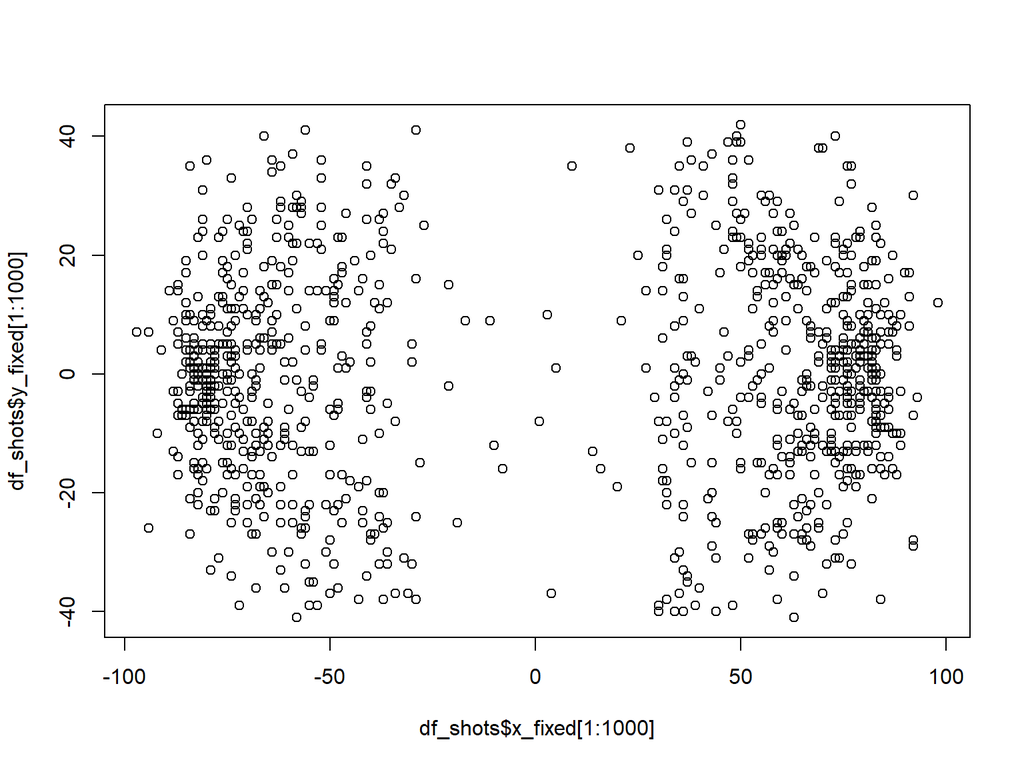

```r
plot(df_shots$x_fixed[1:1000],
     df_shots$y_fixed[1:1000])
```

```r
range(df_shots$x_fixed)
```

```
## [1] -100  100
```

```r
range(df_shots$y_fixed)
```

```
## [1] -43  43
```

# 3. Building the xG Model

The data says that shot attempts come from -100 to +100 feet in the x-direction. Let’s next account for the 11 feet behind the front of the net.

[figure not shown]

# 3. Building the xG Model

Use these coordinates to get the distance from a shot to the center of the front of the net.

Some of the shots are strangely long. Those are probably dump-ins that are technically shots because they reached the opposing goalie.

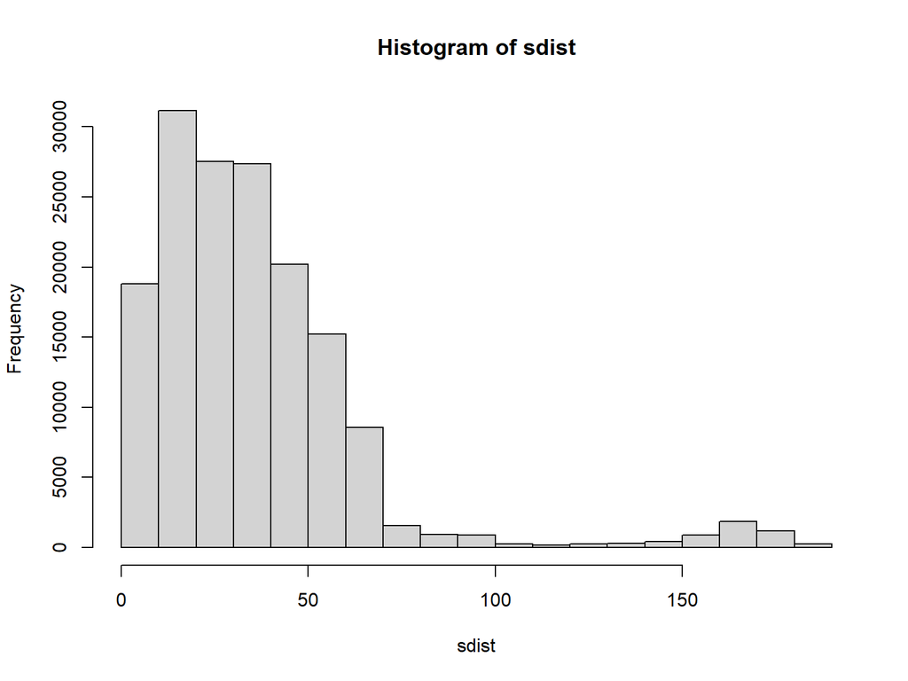

```r
x = df_shots$x_fixed
y = df_shots$y_fixed
etteam = df_shots$event_team_type
etteam[is.na(etteam)] = "home"
sdist = 1*(etteam == "home")*sqrt( (x- 89)^2 + (y)^2) +
        1*(etteam == "away")*sqrt( (x + 89)^2 + (y)^2)

hist(sdist)
```

.

.

.

.

# 3. Building the xG Model

Let’s check out the relationship between distance and goal percentage to see if it makes sense.

```r
sdist_cat = cut(sdist, breaks=seq(from=0, to=200, by=10))
```

First the number of goals (1) and non-scoring shots (0) at each distance interval.

```r
tab = table(sdist_cat, df_shots$is_goal)
tab
```

```
##
## sdist_cat       0     1
##   (0,10]    16639  2147
##   (10,20]   29023  2148
##   (20,30]   25972  1546
##   (30,40]   26365  1013
##   (40,50]   19755   456
##   (50,60]   14973   262
##   (60,70]    8437   111
##   (70,80]    1523    35
##   (80,90]     929    10
##   (90,100]    853    27
##   (100,110]   227    14
##   (110,120]   144    12
##   (120,130]   233    21
##   (130,140]   272    18
##   (140,150]   429    16
##   (150,160]   884    12
##   (160,170]  1839    15
##   (170,180]  1191    12
##   (180,190]   245    16
##   (190,200]     0     0
```

Next with the proportion in each row. Looks like the closest shots do the best.

```r
round(prop.table(tab, 1), 3)
```

```
##
## sdist_cat       0     1
##   (0,10]    0.886 0.114
##   (10,20]   0.931 0.069
##   (20,30]   0.944 0.056
##   (30,40]   0.963 0.037
##   (40,50]   0.977 0.023
##   (50,60]   0.983 0.017
##   (60,70]   0.987 0.013
##   (70,80]   0.978 0.022
##   (80,90]   0.989 0.011
##   (90,100]  0.969 0.031
##   (100,110] 0.942 0.058
##   (110,120] 0.923 0.077
##   (120,130] 0.917 0.083
##   (130,140] 0.938 0.062
##   (140,150] 0.964 0.036
##   (150,160] 0.987 0.013
##   (160,170] 0.992 0.008
##   (170,180] 0.990 0.010
##   (180,190] 0.939 0.061
##   (190,200]
```

.

.

.

.

# 3. Building the xG Model

Now for the shot angle.

To get these, let’s normalize by turning 0-distance shots into those that are positive, but arbitrarily small. Let’s also get all the y-distances the same so we get positive angles.

```r
x_dist=abs(1*(etteam=="home")*(x-89)+ 1*(etteam=="away")*(x+89))

y_dist=abs(y)
x_dist[x_dist==0]=0.00001
y_dist[y_dist==0]=0.00001
```

`atan` is inverse tangent, or arctan.

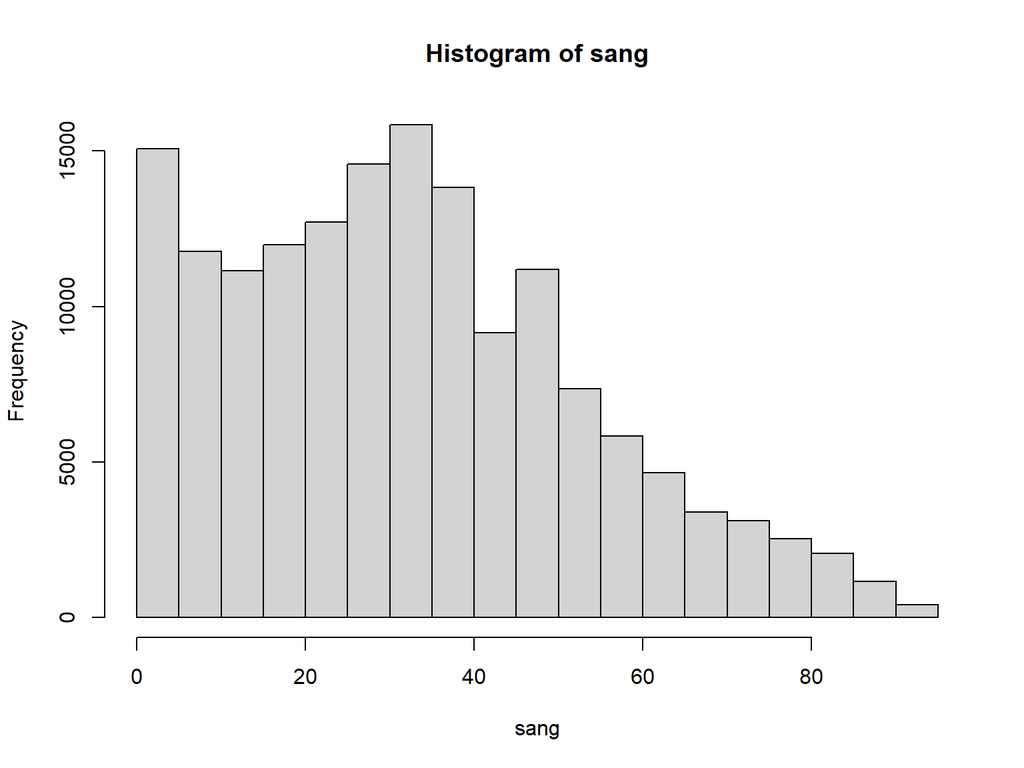

```r
sang=atan(y_dist/x_dist)*180/3.14159
sang[sang < 0]=sang[sang<0]+ 180

hist(sang)
```

.

.

.

.

# 3. Building the xG Model

We then fill in these missing shot angle, shot distance,and player strength codes for blocked or missed shot attempts, for when the dataframe did not have this information recorded (but we were able to derive from shot location).

```r
table(df_shots$shot_angle, useNA = "always")
```

```
##
##     0   0.3   0.4   0.5   0.6   0.7   0.8   0.9     1   1.1   1.2   1.3   1.4
##  2558    10    30     7    19    46    25    51   223   194   128   109   107
##   1.5   1.6   1.7   1.8   1.9     2   2.1   2.2   2.3   2.4   2.5   2.6   2.7
##   105   101    75    88   143   200   135   166   121   124   137   117   130
##   2.8   2.9     3   3.1   3.2   3.3   3.4   3.5   3.6   3.7   3.8   3.9     4
##    58   212   186   126   214    66   195    85   164    97   205   144    95
##   4.1   4.2   4.3   4.4   4.5   4.6   4.7   4.8   4.9     5   5.1   5.2   5.3
##   262   149    67   239    57   109    53   345    96   159    81   359    71
##   5.4   5.5   5.6   5.7   5.8   5.9     6   6.1   6.2   6.3   6.4   6.5   6.6
##   181    58    78   455    63   146   146   103   108   550    23    92   105
##   6.7   6.8   6.9     7   7.1   7.2   7.3   7.4   7.5   7.6   7.7   7.8   7.9
##   195   122    86   107   667    25   104   169    78   185   123    98   129
##     8   8.1   8.2   8.3   8.4   8.5   8.6   8.7   8.8   8.9     9   9.1   9.2
##    78   723    22   102   127   127    90   308    75    85   146   113   118
##   9.3   9.4   9.5   9.6   9.7   9.8   9.9    10  10.1  10.2  10.3  10.4  10.5
##    93    10   719    75    97    94   128   176    92    85   360    85   106
##  10.6  10.7  10.8  10.9    11  11.1  11.2  11.3  11.4  11.5  11.6  11.7  11.8
##   196    95   131   105    98   114    25   811    15    92    93   114   112
##  11.9    12  12.1  12.2  12.3  12.4  12.5  12.6  12.7  12.8  12.9    13  13.1
##   157    92   211    85   174    80   499    41   111   146    95   204   114
##  13.2  13.3  13.4  13.5  13.6  13.7  13.8  13.9    14  14.1  14.2  14.3  14.4
##   151   106   116    80   138   116   111    17   947    15    26   158    67
##  14.5  14.6  14.7  14.8  14.9    15  15.1  15.2  15.3  15.4  15.5  15.6  15.7
##   150   122   170    68   222    69   112    65   352   146   179   117    88
##  15.8  15.9    16  16.1  16.2  16.3  16.4  16.5  16.6  16.7  16.8  16.9    17
##   102   667    13   130    95   145   168    91   133   404    72   152    93
##  17.1  17.2  17.3  17.4  17.5  17.6  17.7  17.8  17.9    18  18.1  18.2  18.3
##   222   148    62   237   146    64   175   105   123   107   139    35    12
##  18.4  18.6  18.7  18.8  18.9    19  19.1  19.2  19.3  19.4  19.5  19.6  19.7
##  1309    17    79    99   131   147   145   101   152   195    82    78   291
##  19.8  19.9    20  20.1  20.2  20.3  20.4  20.5  20.6  20.7  20.8  20.9    21
##    93   119   326   155   172   113   134     6   554   104   112   156   279
##  21.1  21.2  21.3  21.4  21.5  21.6  21.7  21.8  21.9    22  22.1  22.2  22.3
##    67    84   197   162    99   116     8   817    20   156   147   200    96
##  22.4  22.5  22.6  22.7  22.8  22.9    23  23.1  23.2  23.3  23.4  23.5  23.6
##   191   151   267    85   204   103   115    96   643    85   136   141   227
##  23.7  23.8  23.9    24  24.1  24.2  24.3  24.4  24.5  24.6  24.7  24.8  24.9
##   166   127    55   446   202   156   127   371    73   176    93   260   162
##    25  25.1  25.2  25.3  25.4  25.5  25.6  25.7  25.8  25.9    26  26.1  26.2
```

[output cut: 96 more lines]

```
##     3    15     1     8     7     3     3    99     3     3     6     4     1
##   110 110.2 110.6 110.9   111 111.3 111.4 111.8 112.2 112.6 113.2 113.6   114
##    12     1    24     2     7     3     2    52     3     9    25     2    13
## 114.4 114.8   115 115.2 115.3 115.5 116.6 117.9 118.1 118.6 119.1 119.4 119.7
##     3     3     3     1     3     1    75     1     3     7     7     2    26
## 120.3 120.5   121 121.6   122 122.5 122.7 122.9 123.7 124.7   125 125.5   126
##     5     2    28     1     7     5     3     1    27     4     6    15     1
## 126.9 127.9 128.7 129.3 129.8 130.2 130.6 131.2 131.6   132 132.3 132.5   135
##    19     8    15     2     8     1     5     7     1     3     2     1    32
##   138 138.4 138.8 139.4 140.2 141.3 142.1 143.1 144.5   145 146.3 147.5   148
##     1     3     4     2     7     6     1     6     4     2     5     1     3
##   149 150.3 150.9 153.4   156 159.4 164.1   166 167.5 168.7 170.5 171.9 173.7
##     1     3     4     9     1     1     2     1     1     1     2     1     1
## 174.3   180  <NA>   NaN
##     1     1 44378     5
```

```r
idx_to_fill=is.na(df_shots$shot_angle)
df_shots$shot_angle[idx_to_fill]=sang[idx_to_fill]

table(df_shots$shot_angle, useNA = "always")
```

```
##
##                    0 3.29286367291941e-06 3.31189756698253e-06
##                 2558                    1                    4
## 3.33115278539522e-06  3.3506332110408e-06 3.37034281816457e-06
##                   13                   21                   30
## 3.39028567507679e-06 3.41046594695224e-06  3.4308878987304e-06
##                   25                   18                   28
## 3.45155589812034e-06 3.47247441871501e-06 3.49364804321937e-06
##                   19                   12                   12
##  3.5150814667974e-06 3.53677950054307e-06  3.5587470750806e-06
##                    9                   10                   10
## 3.58098924429986e-06 3.60351118923256e-06  3.6263182220758e-06
##                   10                    7                    4
## 3.64941579036928e-06 3.67280948133319e-06 3.69650502637404e-06
##                    4                    2                    8
## 3.72050830576608e-06 3.74482535351619e-06  3.7694623624209e-06
##                    7                    2                    1
## 3.79442568932435e-06 3.81972186058651e-06 3.84535757777166e-06
##                    2                    1                    1
## 3.87133972356741e-06 3.89767536794542e-06 4.00670125236347e-06
##                    1                    1                    1
## 4.06353389424097e-06 4.30795698562388e-06 4.51148251250375e-06
##                    1                    1                    1
## 4.81477545452081e-06 7.44101661153214e-06 8.81474275519959e-06
##                    1                    1                    1
## 1.08105335676976e-05 1.10184284439994e-05 1.12344760605484e-05
##                    4                    5                    3
## 1.14591655817594e-05 1.16930261038361e-05 1.19366308143327e-05
##                    4                    6                    3
## 1.21906016827227e-05 1.24556147627819e-05 1.27324062019549e-05
##                    6                    7                    6
## 1.30217790701811e-05 1.33246111415806e-05 1.36418637878087e-05
##                    7                    6                   10
## 1.39745921728772e-05 1.43239569771991e-05 1.46912379253324e-05
##                   13                    7                    5
## 1.50778494496833e-05 1.54853588942693e-05 1.59155077524434e-05
##                    9                   11                   12
## 1.63702365453703e-05 1.68517140908224e-05 1.73623720935746e-05
##                   20                   13                    9
## 1.79049462214987e-05 1.84825251318696e-05 1.90986093029319e-05
```

[output cut: 1948 more lines]

```
##                    1                    6                    4
##                  145                146.3                147.5
##                    2                    5                    1
##                  148                  149                150.3
##                    3                    1                    3
##                150.9                153.4                  156
##                    4                    9                    1
##                159.4                164.1                  166
##                    1                    2                    1
##                167.5                168.7                170.5
##                    1                    1                    2
##                171.9                173.7                174.3
##                    1                    1                    1
##                  180                 <NA>
##                    1                    0
```

```r
table(df_shots$shot_distance, useNA = "always")
```

```
##
##     0     1   1.4     2   2.2   2.8     3   3.2   3.6     4   4.1   4.2   4.5
##     5    13    14    20    60    32    43   111   133    79   197   101   225
##     5   5.1   5.4   5.7   5.8     6   6.1   6.3   6.4   6.7     7   7.1   7.2
##   459   321   358   150   368   245   487   489   402   493   275   763   491
##   7.3   7.6   7.8     8   8.1   8.2   8.5   8.6   8.9     9   9.1   9.2   9.4
##   535   524   487   303  1122   493   700   471   453   257   452   866   419
##   9.5   9.8   9.9    10  10.2  10.3  10.4  10.6  10.8    11  11.2  11.3  11.4
##   442   356   175   906   375   339   366   307   614   472   553   151   546
##  11.7    12  12.1  12.2  12.4  12.5  12.6  12.7  12.8    13  13.2  13.3  13.4
##   507   573   221   453   204   241   200   114   224   673   206   169   171
##  13.5  13.6  13.9    14  14.1  14.2  14.3  14.4  14.6  14.8  14.9    15  15.1
##   190   374   318   256   240   188   308   155   165   145   319   377   148
##  15.2  15.3  15.5  15.6  15.7  15.8    16  16.1  16.2  16.3  16.4  16.5  16.6
##   156   289   125   202   143   277   167   308   135   292   125   108   290
##  16.8    17  17.1  17.2  17.3  17.5  17.7  17.8  17.9    18  18.1  18.2  18.4
##   145   480   262   144   104   324   269   132   130   409   101   108   551
##  18.6  18.7  18.8  18.9    19  19.1  19.2  19.3  19.4  19.6  19.7  19.8  19.9
##   141    96   111   104   238   213   331   113   219    93   259   197    86
##    20  20.1  20.2  20.4  20.5  20.6  20.8  20.9    21  21.1  21.2  21.3  21.4
##   265   210   299   103   101   415   103    96   232   201   219   106   209
##  21.5  21.6  21.8  21.9    22  22.1  22.2  22.4  22.5  22.6  22.7  22.8    23
##   219   212    77   211   345   157   196   173   189   148   119   389   222
##  23.1  23.2  23.3  23.4  23.5  23.6  23.7  23.8  23.9    24  24.1  24.2  24.3
##   159    81   396   201    78   108    94   171   110   269   189   389    64
##  24.4  24.5  24.6  24.7  24.8    25  25.1  25.2  25.3  25.5  25.6  25.7  25.8
##   185    74    80   247   230   282   246   150   121   367   310    57   109
##  25.9    26  26.1  26.2  26.3  26.4  26.5  26.6  26.7  26.8  26.9    27  27.1
##    82   220   168   336    49   296    43   188    50    85   441   214    57
##  27.2  27.3  27.5  27.6  27.7  27.8  27.9    28  28.1  28.2  28.3  28.4  28.5
##   224   245   245   133   281   223   121   208    53   233   404   175    60
##  28.6  28.7  28.8  28.9    29  29.1  29.2  29.3  29.4  29.5  29.6  29.7  29.8
##   259   101   193    52   240   310   344    50   219   156    46   369   184
##    30  30.1  30.2  30.3  30.4  30.5  30.6  30.7  30.8  30.9    31  31.1  31.2
##   389   206    97    45   321   316   174    56   155   170   175   407   127
##  31.3  31.4  31.6  31.8  31.9    32  32.1  32.2  32.3  32.4  32.5  32.6  32.7
##   191   335   208   367   234   301    80   341   111   160    66   451    62
##  32.8  32.9    33  33.1  33.2  33.3  33.4  33.5  33.6  33.7  33.8  33.9    34
##   270    59   224   240   300   213   170   181   277    51   197    60   408
##  34.1  34.2  34.4  34.5  34.7  34.8  34.9    35  35.1  35.2  35.3  35.4  35.5
```

[output cut: 200 more lines]

```
##     5     3     3     3     2     1     6     3     8     3     4     1     9
## 178.6 178.7 178.9   179 179.1 179.2 179.3 179.4 179.5 179.6 179.7 179.8 179.9
##     1     1     4     1     6     3     2     4     7     3     5     1     1
##   180 180.1 180.2 180.3 180.5 180.6 180.7 180.9   181 181.1 181.2 181.3 181.5
##     9     4     4     4     6     2     3     3     7     3     5     4     7
## 181.6 181.7 181.8 181.9   182 182.1 182.2 182.3 182.5 182.6 182.7 182.8 182.9
##     2     4     6     3     3     4     5     4     4     1     1     2     2
##   183 183.1 183.2 183.3 183.4 183.5 183.6 183.7 183.8   184 184.1 184.2 184.3
##     7     2     7    10     6     3     4     2     1    10     9     1     7
## 184.4 184.5 184.6 184.7 184.8 184.9   185 185.1 185.2 185.3 185.4 185.5 185.6
##     4     5     3     3     4     1     4     5     1     4     2     3     4
## 185.9   186 186.1 186.2 186.3 186.4 186.5 186.6 186.7 186.8   187 187.1 187.2
##     1     5     3     3     2     4     2     3     1     1     2     4     1
## 187.3 187.5 187.7 187.8   188 188.2 188.7 189.1  <NA>
##     3     2     1     1     3     2     1     1 44378
```

```r
idx_to_fill=is.na(df_shots$shot_distance)
df_shots$shot_distance[idx_to_fill]=sdist[idx_to_fill]

table(df_shots$shot_distance, useNA = "always")
```

```
##
##                0                1              1.4  1.4142135623731
##                5               21               14               11
##                2              2.2 2.23606797749979              2.8
##               26               60               18               32
## 2.82842712474619                3 3.16227766016838              3.2
##                9               63               27              111
##              3.6 3.60555127546399                4              4.1
##              133               49              104              197
## 4.12310562561766              4.2 4.24264068711928 4.47213595499958
##               41              101               23               49
##              4.5                5 5.09901951359278              5.1
##              225              553               48              321
##  5.3851648071345              5.4 5.65685424949238              5.7
##               60              358               51              150
##              5.8  5.8309518948453                6 6.08276253029822
##              368               78              286               85
##              6.1              6.3 6.32455532033676              6.4
##              487              489               95              402
## 6.40312423743285              6.7 6.70820393249937                7
##              122              493               99              333
## 7.07106781186548              7.1              7.2 7.21110255092798
##              166              763              491              111
## 7.28010988928052              7.3              7.6 7.61577310586391
##               98              535              524              109
##              7.8 7.81024967590665                8 8.06225774829855
##              487              115              358              280
##              8.1              8.2 8.24621125123532 8.48528137423857
##             1122              493              131               69
##              8.5 8.54400374531753              8.6 8.60232526704263
##              700              121              471              122
##              8.9 8.94427190999916                9 9.05538513813742
##              453              151              325              149
##              9.1              9.2 9.21954445729289              9.4
##              452              866              263              419
##  9.4339811320566 9.48683298050514              9.5              9.8
##              147              151              442              356
##  9.8488578017961 9.89949493661167              9.9               10
##              122               63              175             1136
## 10.0498756211209 10.1980390271856             10.2  10.295630140987
```

[output cut: 1708 more lines]

```
##                1                4                5                1
##            185.3            185.4            185.5            185.6
##                4                2                3                4
##            185.9              186            186.1            186.2
##                1                5                3                3
##            186.3            186.4            186.5            186.6
##                2                4                2                3
##            186.7            186.8              187            187.1
##                1                1                2                4
##            187.2            187.3            187.5            187.7
##                1                3                2                1
##            187.8              188            188.2            188.7
##                1                3                2                1
##            189.1             <NA>
##                1                0
```

```r
table(df_shots$strength_code, useNA = "always")
```

```
##
##     EV     PP     SH   <NA>
## 127112  25964   4753      0
```

```r
idx_to_fill=is.na(df_shots$strength_code)
length(idx_to_fill)
```

```
## [1] 157829
```

```r
df_shots$strength_code[idx_to_fill]="EV"


table(df_shots$strength_code, useNA = "always")
```

```
##
##     EV     PP     SH   <NA>
## 127112  25964   4753      0
```

.

.

.

.

# 3. Building the xG Model

For the blocked shots, replace the NA for goalie with the goalie that was on the ice.

```r
table(df_shots$secondary_type, useNA="always")
```

```
##
##            backhand                 bat        between-legs        BLOCKED_SHOT
##                7970                 419                  77               44375
##              cradle           deflected FAILED_SHOT_ATTEMPT         MISSED_SHOT
##                   9                2294                   3                 237
##                poke                SHOT                slap                snap
##                 440                 374               13351               15702
##              tip-in         wrap-around               wrist                <NA>
##                9977                 892               61709                   0
```

```r
idx_blocked_homeshot=which(df_shots$secondary_type=="BLOCKED_SHOT" &
                df_shots$event_team_type=="home")
  df_shots$event_goalie_name[idx_blocked_homeshot]=
          df_shots$away_goalie[idx_blocked_homeshot]

  idx_blocked_awayshot=which(df_shots$secondary_type=="BLOCKED_SHOT"&
                  df_shots$event_team_type=="away")

df_shots$event_goalie_name[idx_blocked_awayshot]=
                  df_shots$home_goalie[idx_blocked_awayshot]

table(df_shots$secondary_type, useNA="always")
```

```
##
##            backhand                 bat        between-legs        BLOCKED_SHOT
##                7970                 419                  77               44375
##              cradle           deflected FAILED_SHOT_ATTEMPT         MISSED_SHOT
##                   9                2294                   3                 237
##                poke                SHOT                slap                snap
##                 440                 374               13351               15702
##              tip-in         wrap-around               wrist                <NA>
##                9977                 892               61709                   0
```

.

.

.

.

# 3. Building the xG Model

Finally, we model the log-odds of a goal based on the details of the shot attempt, which we then convert into xG by taking the (back-transformed) fitted values.

```r
mod = glm(is_goal ~ shot_distance + shot_angle + secondary_type +
            extra_attacker + strength_code,
              data=df_shots, family="binomial")

summary(mod)
```

```
##
## Call:
## glm(formula = is_goal ~ shot_distance + shot_angle + secondary_type +
##     extra_attacker + strength_code, family = "binomial", data = df_shots)
##
## Coefficients:
##                                     Estimate Std. Error z value Pr(>|z|)
## (Intercept)                       -1.289e+00  4.891e-02 -26.346  < 2e-16 ***
## shot_distance                     -4.260e-02  8.613e-04 -49.462  < 2e-16 ***
## shot_angle                        -1.468e-02  5.556e-04 -26.423  < 2e-16 ***
## secondary_typebat                  2.932e-01  1.533e-01   1.913  0.05574 .
## secondary_typebetween-legs         9.900e-02  3.603e-01   0.275  0.78352
## secondary_typeBLOCKED_SHOT        -1.782e+01  8.004e+01  -0.223  0.82386
## secondary_typecradle               2.137e+00  7.172e-01   2.980  0.00288 **
## secondary_typedeflected           -2.295e-01  8.783e-02  -2.613  0.00897 **
## secondary_typeFAILED_SHOT_ATTEMPT -1.870e+01  1.018e+04  -0.002  0.99853
## secondary_typeMISSED_SHOT         -1.773e+01  1.105e+03  -0.016  0.98720
## secondary_typepoke                 1.648e-01  1.520e-01   1.084  0.27843
## secondary_typeSHOT                -6.037e-01  2.902e-01  -2.080  0.03752 *
## secondary_typeslap                 5.439e-01  6.350e-02   8.565  < 2e-16 ***
## secondary_typesnap                 6.912e-01  5.190e-02  13.319  < 2e-16 ***
## secondary_typetip-in              -2.401e-01  5.632e-02  -4.262 2.02e-05 ***
## secondary_typewrap-around         -8.378e-02  1.470e-01  -0.570  0.56879
## secondary_typewrist                3.187e-01  4.645e-02   6.861 6.85e-12 ***
## extra_attackerTRUE                -1.400e-01  7.779e-02  -1.800  0.07184 .
## strength_codePP                    2.933e-01  3.064e-02   9.574  < 2e-16 ***
## strength_codeSH                    1.619e+00  5.027e-02  32.202  < 2e-16 ***
## ---
## Signif. codes:  0 '***' 0.001 '**' 0.01 '*' 0.05 '.' 0.1 ' ' 1
##
## (Dispersion parameter for binomial family taken to be 1)
##
##     Null deviance: 62690  on 157828  degrees of freedom
## Residual deviance: 52530  on 157809  degrees of freedom
## AIC: 52570
##
## Number of Fisher Scoring iterations: 19
```

We save the fitted values as our xG model output.

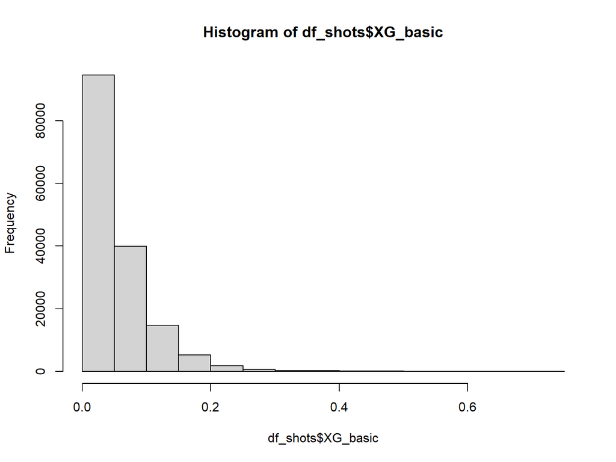

```r
df_shots$XG_basic = mod$fitted.values
hist(df_shots$XG_basic)
```

.

.

.

.

# 4. Improving the model

How good is the model?

The McFadden R-squared for generalized linear models is close to equivalent for the R-squared for linear models, telling us roughtly how much variance has been explained by our model. Can we do better than 16.2%?

```r
1 - mod$deviance / mod$null.deviance
```

```
## [1] 0.1620705
```

.

.

.

.

# 4. Improving the model

The proportion of times something is a goal does seem to be increasing as the xG increases.

```r
xg_cat = cut(df_shots$XG_basic, breaks=seq(from=0, to=1, by=1/40))

tab = table(xg_cat, df_shots$is_goal)
tab
```

```
##
## xg_cat             0     1
##   (0,0.025]    63957   286
##   (0.025,0.05] 29612   736
##   (0.05,0.075] 23218  1472
##   (0.075,0.1]  13690  1571
##   (0.1,0.125]   7938  1294
##   (0.125,0.15]  4586   910
##   (0.15,0.175]  2591   552
##   (0.175,0.2]   1694   364
##   (0.2,0.225]    950   205
##   (0.225,0.25]   495   114
##   (0.25,0.275]   352    80
##   (0.275,0.3]    173    41
##   (0.3,0.325]    111    38
##   (0.325,0.35]   104    27
##   (0.35,0.375]    79    33
##   (0.375,0.4]     80    28
##   (0.4,0.425]     77    32
##   (0.425,0.45]    61    29
##   (0.45,0.475]    56    19
##   (0.475,0.5]     40    20
##   (0.5,0.525]     23    13
##   (0.525,0.55]    22    10
##   (0.55,0.575]    10    14
##   (0.575,0.6]      7     6
##   (0.6,0.625]      5     1
##   (0.625,0.65]     1     1
##   (0.65,0.675]     0     0
##   (0.675,0.7]      0     0
##   (0.7,0.725]      1     0
##   (0.725,0.75]     0     0
##   (0.75,0.775]     0     0
##   (0.775,0.8]      0     0
##   (0.8,0.825]      0     0
##   (0.825,0.85]     0     0
##   (0.85,0.875]     0     0
##   (0.875,0.9]      0     0
##   (0.9,0.925]      0     0
##   (0.925,0.95]     0     0
##   (0.95,0.975]     0     0
##   (0.975,1]        0     0
```

```r
round(prop.table(tab, 1), 3)
```

```
##
## xg_cat             0     1
##   (0,0.025]    0.996 0.004
##   (0.025,0.05] 0.976 0.024
##   (0.05,0.075] 0.940 0.060
##   (0.075,0.1]  0.897 0.103
##   (0.1,0.125]  0.860 0.140
##   (0.125,0.15] 0.834 0.166
##   (0.15,0.175] 0.824 0.176
##   (0.175,0.2]  0.823 0.177
##   (0.2,0.225]  0.823 0.177
##   (0.225,0.25] 0.813 0.187
##   (0.25,0.275] 0.815 0.185
##   (0.275,0.3]  0.808 0.192
##   (0.3,0.325]  0.745 0.255
##   (0.325,0.35] 0.794 0.206
##   (0.35,0.375] 0.705 0.295
##   (0.375,0.4]  0.741 0.259
##   (0.4,0.425]  0.706 0.294
##   (0.425,0.45] 0.678 0.322
##   (0.45,0.475] 0.747 0.253
##   (0.475,0.5]  0.667 0.333
##   (0.5,0.525]  0.639 0.361
##   (0.525,0.55] 0.688 0.312
##   (0.55,0.575] 0.417 0.583
##   (0.575,0.6]  0.538 0.462
##   (0.6,0.625]  0.833 0.167
##   (0.625,0.65] 0.500 0.500
##   (0.65,0.675]
##   (0.675,0.7]
##   (0.7,0.725]  1.000 0.000
##   (0.725,0.75]
##   (0.75,0.775]
##   (0.775,0.8]
##   (0.8,0.825]
##   (0.825,0.85]
##   (0.85,0.875]
##   (0.875,0.9]
##   (0.9,0.925]
##   (0.925,0.95]
##   (0.95,0.975]
##   (0.975,1]
```

.

.

.

.

# 4. Improving the model

Currently our model only uses shot distance, shot angle, shot type (`secondary_type`), whether there is an `extra_attacker` on the ice from a pulled goalie on the shooter’s team, and a marker for whether the team shooting is short handed, even strength, or on the power play (`strength_code`)

```r
mod = glm(is_goal ~ shot_distance +
            shot_angle +
            secondary_type +
            extra_attacker +
            strength_code,
              data=df_shots, family="binomial")
```

What can we do to improve this model? We have a LOT of degrees of freedom to work with.

.

.

.

.

# 4. Improving the model

- We can include the period, which may matter as players fatigue, and also because of the bench-goalie distance is backwards in period 2.
- We’ll force R to interpret period as a category with `as.factor` rather than a continuous number.
- This model won’t work in overtime, but overtime is already a different beast because it’s 3v3 so using a 5v5 model may be inappropriate.

```r
df_shots$period_factor = as.factor(df_shots$period)
table(df_shots$period_factor)
```

```
##
##     1     2     3
## 51840 54077 51912
```

The residual deviance to beat is 52530

```r
mod2 = glm(is_goal ~ shot_distance +
            shot_angle +
            secondary_type +
            extra_attacker +
            strength_code +
            period_factor,
              data=df_shots, family="binomial")

summary(mod2)
```

```
##
## Call:
## glm(formula = is_goal ~ shot_distance + shot_angle + secondary_type +
##     extra_attacker + strength_code + period_factor, family = "binomial",
##     data = df_shots)
##
## Coefficients:
##                                     Estimate Std. Error z value Pr(>|z|)
## (Intercept)                       -1.363e+00  5.201e-02 -26.212  < 2e-16 ***
## shot_distance                     -4.267e-02  8.612e-04 -49.544  < 2e-16 ***
## shot_angle                        -1.471e-02  5.556e-04 -26.467  < 2e-16 ***
## secondary_typebat                  2.961e-01  1.533e-01   1.931  0.05345 .
## secondary_typebetween-legs         9.846e-02  3.605e-01   0.273  0.78478
## secondary_typeBLOCKED_SHOT        -1.781e+01  8.000e+01  -0.223  0.82379
## secondary_typecradle               2.155e+00  7.178e-01   3.002  0.00269 **
## secondary_typedeflected           -2.298e-01  8.785e-02  -2.615  0.00891 **
## secondary_typeFAILED_SHOT_ATTEMPT -1.869e+01  1.017e+04  -0.002  0.99853
## secondary_typeMISSED_SHOT         -1.773e+01  1.105e+03  -0.016  0.98720
## secondary_typepoke                 1.636e-01  1.521e-01   1.075  0.28218
## secondary_typeSHOT                -6.065e-01  2.904e-01  -2.089  0.03675 *
## secondary_typeslap                 5.441e-01  6.351e-02   8.567  < 2e-16 ***
## secondary_typesnap                 6.932e-01  5.191e-02  13.354  < 2e-16 ***
## secondary_typetip-in              -2.383e-01  5.633e-02  -4.231 2.33e-05 ***
## secondary_typewrap-around         -8.701e-02  1.470e-01  -0.592  0.55403
## secondary_typewrist                3.202e-01  4.646e-02   6.893 5.47e-12 ***
## extra_attackerTRUE                -2.149e-01  7.914e-02  -2.715  0.00663 **
## strength_codePP                    2.933e-01  3.066e-02   9.567  < 2e-16 ***
## strength_codeSH                    1.604e+00  5.035e-02  31.857  < 2e-16 ***
## period_factor2                     6.386e-02  2.982e-02   2.142  0.03220 *
## period_factor3                     1.666e-01  3.020e-02   5.518 3.43e-08 ***
## ---
## Signif. codes:  0 '***' 0.001 '**' 0.01 '*' 0.05 '.' 0.1 ' ' 1
##
## (Dispersion parameter for binomial family taken to be 1)
##
##     Null deviance: 62690  on 157828  degrees of freedom
## Residual deviance: 52498  on 157807  degrees of freedom
## AIC: 52542
##
## Number of Fisher Scoring iterations: 19
```

```r
1 - mod2$deviance / mod2$null.deviance
```

```
## [1] 0.1625678
```

…just barely. Not the most inspiring improvement. What else can we do?

.

.

.

.

# 4. Improving the model

- We could look at the number of shot attempts that have happened in the last 10, 20, or 30 seconds, because if multiple attempts happen in quick succession, that might indicate that the goalie is already out of position.
- We need a way to count the number of shots that have happened recently against a given goalie. This is going to be approximate unless we factor in things like faceoffs, that would be messy (a good exercise for home though)

Here’s what we’ll do. First, we’ll split the dataset in ‘shots by home’ and ‘shots by away’, and take the `diff()` of `period_seconds` for each shot. Then we’ll do something similar to see the time since two shots ago, and three shots ago. Any large values or negative values will be increased to 120 seconds, an arbitrary number that will indicate that the goalie and defenders are back in position, lines changed, etc.

Finally, we’ll merge the two datasets back, and sort them back into the original order using `event_id`

.

.

.

.

# 4. Improving the model

First home with one shot (looks exponential, why?)

```r
df_shots = arrange(df_shots, event_id)
```

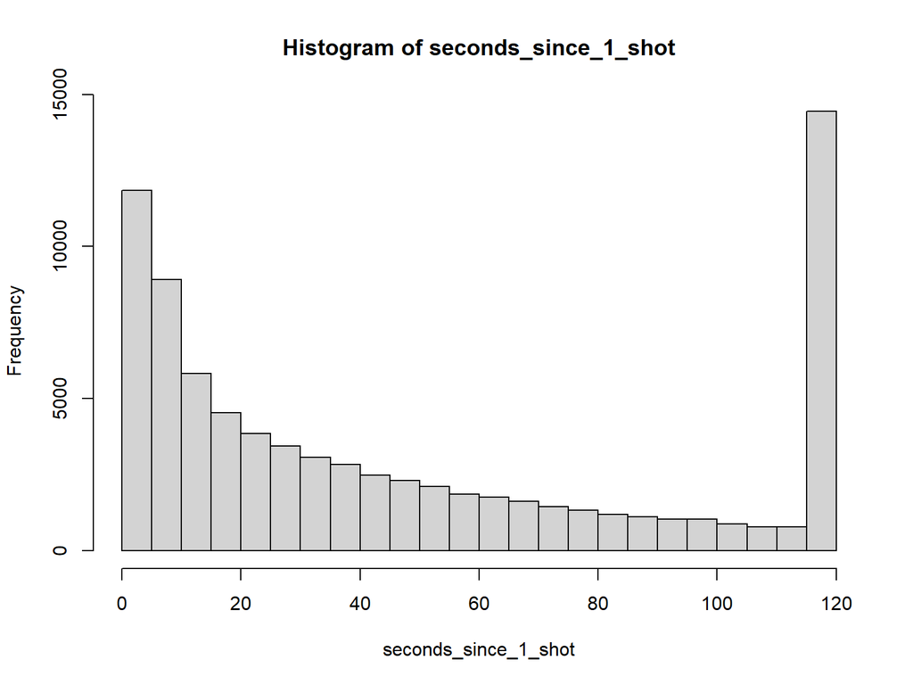

```r
df_shots_home = subset(df_shots, event_team_type == "home")
seconds_since_1_shot = c(120, diff(df_shots_home$period_seconds))
seconds_since_1_shot[seconds_since_1_shot < 0 | seconds_since_1_shot > 120] = 120
hist(seconds_since_1_shot)
```

…home two shots (looks like a gamma, why?)

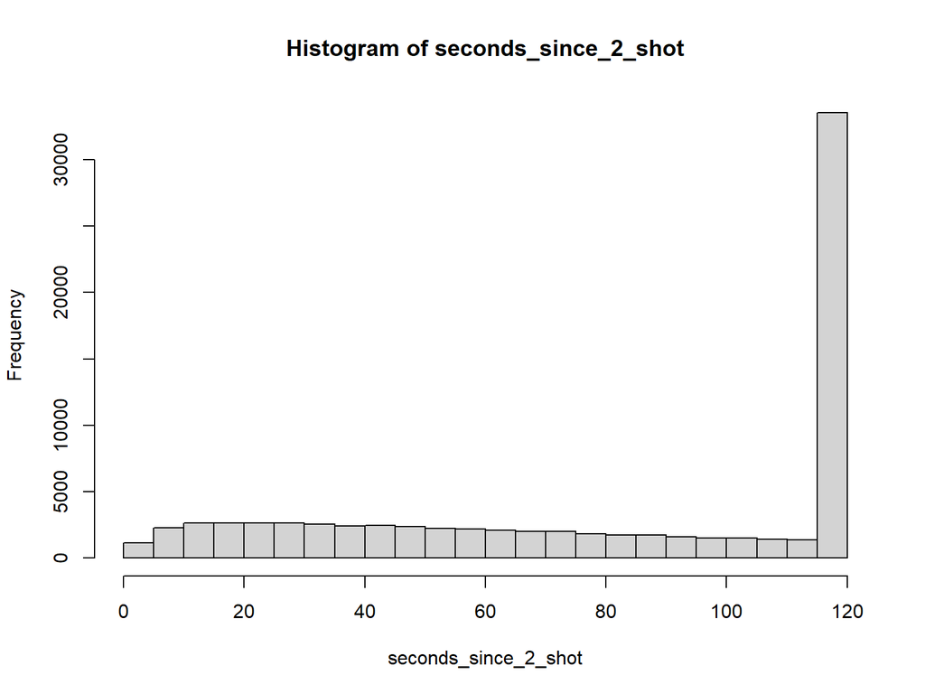

```r
Nshots = nrow(df_shots_home)
seconds_since_2_shot = c(120, 120,
               df_shots_home$period_seconds[-c(1,2)] -
              df_shots_home$period_seconds[-c(Nshots-1, Nshots)]   )
seconds_since_2_shot[seconds_since_2_shot < 0 | seconds_since_2_shot > 120] = 120
hist(seconds_since_2_shot)
```

…home three shots (looks like a gamma again, why?)

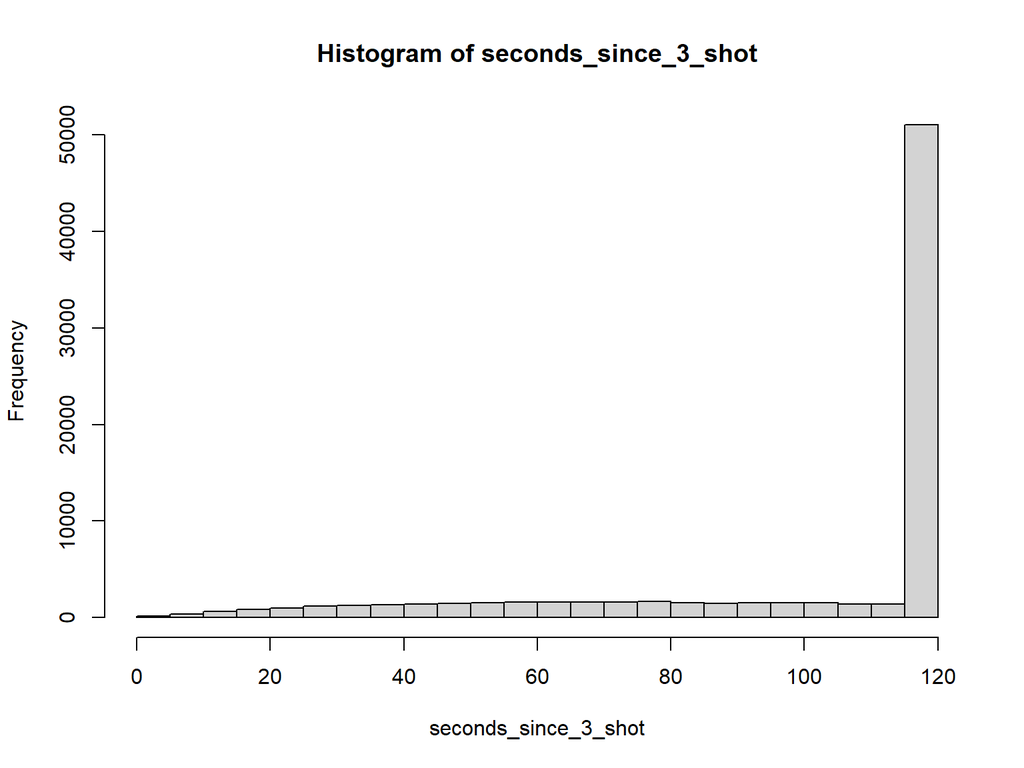

```r
seconds_since_3_shot = c(120, 120, 120,
               df_shots_home$period_seconds[-c(1,2,3)] -
              df_shots_home$period_seconds[-c(Nshots-2, Nshots-1, Nshots)]   )
seconds_since_3_shot[seconds_since_3_shot < 0 | seconds_since_3_shot > 120] = 120
hist(seconds_since_3_shot)
```

And putting these in

```r
df_shots_home$seconds_since_1 = seconds_since_1_shot
df_shots_home$seconds_since_2 = seconds_since_2_shot
df_shots_home$seconds_since_3 = seconds_since_3_shot
```

.

.

.

.

# 4. Improving the model

Repeat with away team

```r
df_shots_away = subset(df_shots, event_team_type == "away")
seconds_since_1_shot = c(120, diff(df_shots_away$period_seconds))
seconds_since_1_shot[seconds_since_1_shot < 0 | seconds_since_1_shot > 120] = 120
```

```r
Nshots = nrow(df_shots_away)
seconds_since_2_shot = c(120, 120,
               df_shots_away$period_seconds[-c(1,2)] -
              df_shots_away$period_seconds[-c(Nshots-1, Nshots)]   )
seconds_since_2_shot[seconds_since_2_shot < 0 | seconds_since_2_shot > 120] = 120
```

```r
seconds_since_3_shot = c(120, 120, 120,
               df_shots_away$period_seconds[-c(1,2,3)] -
              df_shots_away$period_seconds[-c(Nshots-2, Nshots-1, Nshots)]   )
seconds_since_3_shot[seconds_since_3_shot < 0 | seconds_since_3_shot > 120] = 120
```

```r
df_shots_away$seconds_since_1 = seconds_since_1_shot
df_shots_away$seconds_since_2 = seconds_since_2_shot
df_shots_away$seconds_since_3 = seconds_since_3_shot
```

.

.

.

.

# 4. Improving the model

Next we merge the datasets

```r
df_shots2 = rbind(df_shots_home, df_shots_away)
df_shots2 = arrange(df_shots2, event_id)
all(df_shots$event_id == df_shots2$event_id)
```

```
## [1] TRUE
```

Finally, we something that counts the number of recent shots (up to 3 in the last 10, 20, 30 seconds)

```r
df_shots2$shots_last_5 = 1*(df_shots2$seconds_since_1 <= 5) +
                          1*(df_shots2$seconds_since_2 <= 5) +
                          1*(df_shots2$seconds_since_3 <= 5)

df_shots2$shots_last_10 = 1*(df_shots2$seconds_since_1 <= 10) +
                          1*(df_shots2$seconds_since_2 <= 10) +
                          1*(df_shots2$seconds_since_3 <= 10)

df_shots2$shots_last_20 = 1*(df_shots2$seconds_since_1 <= 20) +
                          1*(df_shots2$seconds_since_2 <= 20) +
                          1*(df_shots2$seconds_since_3 <= 20)

df_shots2$shots_last_30 = 1*(df_shots2$seconds_since_1 <= 30) +
                          1*(df_shots2$seconds_since_2 <= 30) +
                          1*(df_shots2$seconds_since_3 <= 30)
```

```r
table(df_shots2$shots_last_5)
```

```
##
##      0      1      2      3
## 134648  20925   2004    252
```

```r
table(df_shots2$shots_last_10)
```

```
##
##      0      1      2      3
## 117341  33861   5715    912
```

```r
table(df_shots2$shots_last_20)
```

```
##
##     0     1     2     3
## 97234 43656 13181  3758
```

```r
table(df_shots2$shots_last_30)
```

```
##
##     0     1     2     3
## 83054 47779 19087  7909
```

.

.

.

.

# 4. Improving the model

Now let’s see it in the model.

```r
mod3 = glm(is_goal ~ shot_distance +
            shot_angle +
            secondary_type +
            extra_attacker +
            strength_code +
            period_factor +
            shots_last_5 +
             shots_last_10 +
             shots_last_20 +
             shots_last_30,
              data=df_shots2, family="binomial")

summary(mod3)
```

```
##
## Call:
## glm(formula = is_goal ~ shot_distance + shot_angle + secondary_type +
##     extra_attacker + strength_code + period_factor + shots_last_5 +
##     shots_last_10 + shots_last_20 + shots_last_30, family = "binomial",
##     data = df_shots2)
##
## Coefficients:
##                                     Estimate Std. Error z value Pr(>|z|)
## (Intercept)                       -1.383e+00  5.418e-02 -25.526  < 2e-16 ***
## shot_distance                     -4.258e-02  8.898e-04 -47.854  < 2e-16 ***
## shot_angle                        -1.471e-02  5.557e-04 -26.473  < 2e-16 ***
## secondary_typebat                  2.894e-01  1.535e-01   1.885  0.05937 .
## secondary_typebetween-legs         9.151e-02  3.606e-01   0.254  0.79967
## secondary_typeBLOCKED_SHOT        -1.782e+01  8.000e+01  -0.223  0.82376
## secondary_typecradle               2.163e+00  7.182e-01   3.011  0.00260 **
## secondary_typedeflected           -2.341e-01  8.799e-02  -2.661  0.00779 **
## secondary_typeFAILED_SHOT_ATTEMPT -1.867e+01  1.017e+04  -0.002  0.99853
## secondary_typeMISSED_SHOT         -1.773e+01  1.105e+03  -0.016  0.98720
## secondary_typepoke                 1.573e-01  1.524e-01   1.032  0.30223
## secondary_typeSHOT                -6.045e-01  2.904e-01  -2.081  0.03739 *
## secondary_typeslap                 5.394e-01  6.355e-02   8.488  < 2e-16 ***
## secondary_typesnap                 6.926e-01  5.196e-02  13.330  < 2e-16 ***
## secondary_typetip-in              -2.402e-01  5.687e-02  -4.223 2.41e-05 ***
## secondary_typewrap-around         -9.020e-02  1.471e-01  -0.613  0.53988
## secondary_typewrist                3.185e-01  4.648e-02   6.852 7.30e-12 ***
## extra_attackerTRUE                -2.236e-01  7.930e-02  -2.820  0.00480 **
## strength_codePP                    2.868e-01  3.082e-02   9.308  < 2e-16 ***
## strength_codeSH                    1.617e+00  5.076e-02  31.857  < 2e-16 ***
## period_factor2                     6.319e-02  2.982e-02   2.119  0.03412 *
## period_factor3                     1.667e-01  3.021e-02   5.519 3.41e-08 ***
## shots_last_5                      -8.246e-03  4.215e-02  -0.196  0.84491
## shots_last_10                     -6.478e-02  4.167e-02  -1.554  0.12007
## shots_last_20                      9.103e-02  3.790e-02   2.402  0.01632 *
## shots_last_30                     -9.118e-03  2.797e-02  -0.326  0.74439
## ---
## Signif. codes:  0 '***' 0.001 '**' 0.01 '*' 0.05 '.' 0.1 ' ' 1
##
## (Dispersion parameter for binomial family taken to be 1)
##
##     Null deviance: 62690  on 157828  degrees of freedom
## Residual deviance: 52487  on 157803  degrees of freedom
## AIC: 52539
##
## Number of Fisher Scoring iterations: 19
```

Well that’s disappointing.

.

.

.

.

# 4. Improving the model

One last attempt.

We’ll use `event_goalie_name` for this

```r
unique(df_shots2$event_goalie_name)
```

```
##  [1] "Juuse Saros"          "Jonas Johansson"      NA
##  [4] "Petr Mrazek"          "Tristan Jarry"        "Adin Hill"
##  [7] "Philipp Grubauer"     "Joonas Korpisalo"     "Frederik Andersen"
## [10] "Jake Allen"           "Ilya Samsonov"        "Arvid Soderblom"
## [13] "Linus Ullmark"        "Jacob Markstrom"      "Connor Hellebuyck"
## [16] "Cam Talbot"           "Alexandar Georgiev"   "Thatcher Demko"
## [19] "Jack Campbell"        "Stuart Skinner"       "Casey DeSmith"
## [22] "Igor Shesterkin"      "Devon Levi"           "Carter Hart"
## [25] "Elvis Merzlikins"     "Vitek Vanecek"        "Ville Husso"
## [28] "Jake Oettinger"       "Jordan Binnington"    "Filip Gustavsson"
## [31] "Sergei Bobrovsky"     "Kaapo Kahkonen"       "Logan Thompson"
## [34] "Akira Schmid"         "Karel Vejmelka"       "Charlie Lindgren"
## [37] "Anton Forsberg"       "Jeremy Swayman"       "Spencer Martin"
## [40] "Sam Montembeault"     "Alex Nedeljkovic"     "Ilya Sorokin"
## [43] "Joey Daccord"         "Mackenzie Blackwood"  "John Gibson"
```

[output cut: 18 more lines]

```r
length(which(is.na(df_shots2$event_goalie_name)))
```

```
## [1] 1808
```

Let’s investigate

```r
idx_no_goalie = which(is.na(df_shots2$event_goalie_name))
idx_no_goalie[1:10]
```

```
##  [1]  89 124 126 263 264 312 402 519 542 770
```

```r
table(df_shots2$is_goal[idx_no_goalie])
```

```
##
##   0   1
## 950 858
```

```r
table(df_shots2$strength_state[idx_no_goalie])
```

```
##
## 1v0 4v4 4v5 4v6 5v4 5v5 5v6 6v4 6v5
##  18   9  77  70  68 598 948   1  19
```

Almost half of these are goals, we could probably just replace the NA with “Empty Net” and let the model find the effect size. 18 of these are penalty shots (1v0 strength state), but that’s too rare and too different for our model.

We’ll just have to remember to make the “Empty Net” replacement when applying this to new data.

```r
df_shots2$event_goalie_name[idx_no_goalie] = "Empty Net"
```

.

.

.

.

# 4. Improving the model

Now to make the model. Ideally we would use a random effects model like glmer for this but for computational reasons we can’t.

```r
mod4 = glm(is_goal ~ shot_distance +
            shot_angle +
            secondary_type +
            extra_attacker +
            strength_code +
            period_factor +
            shots_last_5 +
             shots_last_10 +
             shots_last_20 +
             shots_last_30 +
             event_goalie_name,
              data=df_shots2, family="binomial")
summary(mod4)
```

```
##
## Call:
## glm(formula = is_goal ~ shot_distance + shot_angle + secondary_type +
##     extra_attacker + strength_code + period_factor + shots_last_5 +
##     shots_last_10 + shots_last_20 + shots_last_30 + event_goalie_name,
##     family = "binomial", data = df_shots2)
##
## Coefficients:
##                                         Estimate Std. Error z value Pr(>|z|)
## (Intercept)                           -1.266e+00  1.291e-01  -9.806  < 2e-16
## shot_distance                         -5.388e-02  9.716e-04 -55.454  < 2e-16
## shot_angle                            -1.501e-02  5.767e-04 -26.031  < 2e-16
## secondary_typebat                      2.965e-01  1.580e-01   1.876 0.060606
## secondary_typebetween-legs             1.320e-01  3.620e-01   0.365 0.715475
## secondary_typeBLOCKED_SHOT            -1.939e+01  7.035e+01  -0.276 0.782839
## secondary_typecradle                   2.242e+00  7.247e-01   3.094 0.001974
## secondary_typedeflected               -2.273e-01  9.040e-02  -2.514 0.011921
## secondary_typeFAILED_SHOT_ATTEMPT     -2.500e+01  1.016e+04  -0.002 0.998037
## secondary_typeMISSED_SHOT             -1.757e+01  1.100e+03  -0.016 0.987249
## secondary_typepoke                     1.666e-01  1.589e-01   1.048 0.294544
## secondary_typeSHOT                    -2.025e+00  5.278e-01  -3.836 0.000125
## secondary_typeslap                     8.954e-01  6.620e-02  13.526  < 2e-16
## secondary_typesnap                     8.714e-01  5.445e-02  16.005  < 2e-16
## secondary_typetip-in                  -1.934e-01  5.877e-02  -3.291 0.000997
## secondary_typewrap-around             -2.021e-01  1.568e-01  -1.289 0.197516
## secondary_typewrist                    4.076e-01  4.898e-02   8.321  < 2e-16
## extra_attackerTRUE                    -1.722e-01  8.307e-02  -2.073 0.038211
## strength_codePP                        2.854e-01  3.147e-02   9.070  < 2e-16
## strength_codeSH                        5.658e-02  8.577e-02   0.660 0.509499
## period_factor2                         8.766e-02  3.065e-02   2.860 0.004233
## period_factor3                         1.252e-02  3.228e-02   0.388 0.698111
## shots_last_5                          -7.404e-02  4.359e-02  -1.699 0.089376
## shots_last_10                         -5.717e-02  4.300e-02  -1.330 0.183635
## shots_last_20                          8.240e-02  3.910e-02   2.107 0.035098
## shots_last_30                         -1.210e-04  2.886e-02  -0.004 0.996654
## event_goalie_nameAkira Schmid          1.928e-01  1.947e-01   0.990 0.322009
## event_goalie_nameAlex Lyon             3.154e-03  1.531e-01   0.021 0.983569
## event_goalie_nameAlex Nedeljkovic      6.893e-02  1.598e-01   0.431 0.666306
## event_goalie_nameAlexandar Georgiev    1.292e-01  1.425e-01   0.906 0.364720
## event_goalie_nameAndrei Vasilevskiy    1.317e-01  1.478e-01   0.891 0.372978
```

[output cut: 213 more lines]

```
## event_goalie_nameUkko-Pekka Luukkonen
## event_goalie_nameVille Husso
## event_goalie_nameVitek Vanecek
## event_goalie_nameYaniv Perets
## event_goalie_nameYaroslav Askarov
## ---
## Signif. codes:  0 '***' 0.001 '**' 0.01 '*' 0.05 '.' 0.1 ' ' 1
##
## (Dispersion parameter for binomial family taken to be 1)
##
##     Null deviance: 62690  on 157828  degrees of freedom
## Residual deviance: 48326  on 157705  degrees of freedom
## AIC: 48574
##
## Number of Fisher Scoring iterations: 19
```

.

.

.

.

# 4. Improving the model

It looks like the individual goalie doesn’t matter much for xG, but the fact that there is a goalie at all does matter.

Let’s try a simpler one that just marks if the net is empty

```r
df_shots2$event_goalie_name[df_shots2$event_goalie_name == "Empty Net"] = NA
df_shots2$is_empty_net = 1*(is.na(df_shots2$event_goalie_name))

mod5 = glm(is_goal ~ shot_distance +
            shot_angle +
            secondary_type +
            extra_attacker +
            strength_code +
            period_factor +
            shots_last_5 +
             shots_last_10 +
             shots_last_20 +
             shots_last_30 +
             is_empty_net,
              data=df_shots2, family="binomial")
summary(mod5)
```

```
##
## Call:
## glm(formula = is_goal ~ shot_distance + shot_angle + secondary_type +
##     extra_attacker + strength_code + period_factor + shots_last_5 +
##     shots_last_10 + shots_last_20 + shots_last_30 + is_empty_net,
##     family = "binomial", data = df_shots2)
##
## Coefficients:
##                                     Estimate Std. Error z value Pr(>|z|)
## (Intercept)                       -1.220e+00  5.646e-02 -21.608  < 2e-16 ***
## shot_distance                     -5.385e-02  9.691e-04 -55.565  < 2e-16 ***
## shot_angle                        -1.499e-02  5.752e-04 -26.055  < 2e-16 ***
## secondary_typebat                  2.945e-01  1.578e-01   1.866 0.062035 .
## secondary_typebetween-legs         1.006e-01  3.610e-01   0.279 0.780486
## secondary_typeBLOCKED_SHOT        -1.939e+01  7.043e+01  -0.275 0.783111
## secondary_typecradle               2.154e+00  7.185e-01   2.997 0.002724 **
## secondary_typedeflected           -2.252e-01  9.018e-02  -2.498 0.012505 *
## secondary_typeFAILED_SHOT_ATTEMPT -2.498e+01  1.016e+04  -0.002 0.998038
## secondary_typeMISSED_SHOT         -1.757e+01  1.100e+03  -0.016 0.987262
## secondary_typepoke                 1.507e-01  1.586e-01   0.951 0.341787
## secondary_typeSHOT                -2.017e+00  5.279e-01  -3.820 0.000134 ***
## secondary_typeslap                 8.976e-01  6.607e-02  13.586  < 2e-16 ***
## secondary_typesnap                 8.701e-01  5.429e-02  16.027  < 2e-16 ***
## secondary_typetip-in              -1.975e-01  5.865e-02  -3.367 0.000759 ***
## secondary_typewrap-around         -2.060e-01  1.566e-01  -1.316 0.188289
## secondary_typewrist                4.073e-01  4.888e-02   8.333  < 2e-16 ***
## extra_attackerTRUE                -1.792e-01  8.281e-02  -2.164 0.030446 *
## strength_codePP                    2.832e-01  3.136e-02   9.033  < 2e-16 ***
## strength_codeSH                    5.979e-02  8.558e-02   0.699 0.484752
## period_factor2                     8.600e-02  3.058e-02   2.813 0.004916 **
## period_factor3                     1.008e-02  3.219e-02   0.313 0.754209
## shots_last_5                      -7.310e-02  4.350e-02  -1.681 0.092849 .
## shots_last_10                     -6.140e-02  4.293e-02  -1.430 0.152621
## shots_last_20                      8.353e-02  3.903e-02   2.140 0.032354 *
## shots_last_30                      1.142e-03  2.881e-02   0.040 0.968372
## is_empty_net                       6.455e+00  1.457e-01  44.302  < 2e-16 ***
## ---
## Signif. codes:  0 '***' 0.001 '**' 0.01 '*' 0.05 '.' 0.1 ' ' 1
##
## (Dispersion parameter for binomial family taken to be 1)
##
##     Null deviance: 62690  on 157828  degrees of freedom
## Residual deviance: 48457  on 157802  degrees of freedom
## AIC: 48511
##
## Number of Fisher Scoring iterations: 19
```

Using all goalies: 48326 residual deviance

Using just “Empty net”: 48457 residual deviance

Not a big enough improvement to justify including that and dealing with new goalies later.

```r
1 - mod5$deviance / mod5$null.deviance
```

```
## [1] 0.2270301
```

All those improvements got us from 16.2% R-squared to 22.7% R-squared. Worth the effort to look, eh?

.

.

.

.